# Lab 8: Solution

1. Load in the Lending Club data. Drop loans with empty loan_status. Calculate the average fico score as we did in class.

```r
set.seed(364)
library(dplyr)
library(ggplot2)
library(stargazer)
library(descr)
library(class)
loan <- read.csv("LoanStats3a_securev1.csv", skip=1)
loan <- filter(loan, loan_status!="")
loan$status <- ifelse(loan$loan_status=="Current" |
                      loan$loan_status=="Fully Paid" |
                          loan$loan_status=="Does not meet the credit policy.  Status:Fully Paid","good","bad")
table(loan$status)
```

```
##
##   bad  good
##  6371 36164
```

```r
loan$fico <- (loan$fico_range_high+loan$fico_range_low)/2
```

2. Do you think loan size (variable `loan_amnt`) would be a good feature for our model predicting defaults? Present evidence to support your answer.

Let’s see if loan size is related to default.

```r
stargazer(select(filter(loan, status=="good"),loan_amnt), median = TRUE, type = "text", digits = 0)
```

```
##
## ==================================================
## Statistic   N     Mean  St. Dev. Min Median  Max
## --------------------------------------------------
## loan_amnt 36,164 10,977  7,313   500 9,600  35,000
## --------------------------------------------------
```

```r
stargazer(select(filter(loan, status=="bad"),loan_amnt), median = TRUE, type = "text", digits = 0)
```

```
##
## =================================================
## Statistic   N    Mean  St. Dev. Min Median  Max
## -------------------------------------------------
## loan_amnt 6,371 11,727  7,916   500 10,000 35,000
## -------------------------------------------------
```

```r
t.test(loan$loan_amnt ~ loan$status)
```

```
##
##  Welch Two Sample t-test
##
## data:  loan$loan_amnt by loan$status
## t = 7.044, df = 8395.7, p-value = 2.016e-12
## alternative hypothesis: true difference in means is not equal to 0
## 95 percent confidence interval:
##  540.7653 957.7950
## sample estimates:
##  mean in group bad mean in group good
##           11726.77           10977.49
```

The difference is highly statistically significant. However, it may be driven by a few outliers, so let’s see the box plot.

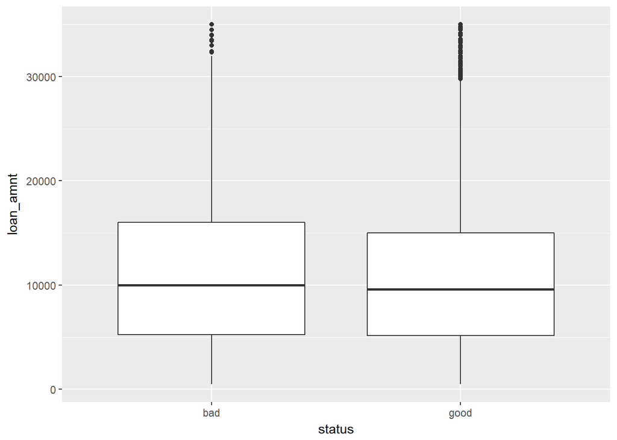

```r
ggplot(loan, aes(x=status, y= loan_amnt)) + geom_boxplot()
```

The difference in loan amounts of good and bad loans does not jump out from box plots. The 75th percentile is a bit higher for bad loans but overall the differences, though statistically significant, do not seem large. To get another view, let’s plot the density of loan size by good or bad loans.

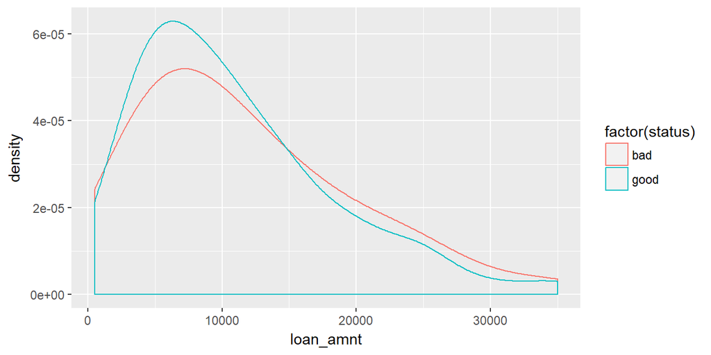

```r
ggplot(loan, aes(x=loan_amnt, color=factor(status))) + geom_density(adjust=3)
```

The density for good loans is a bit higher for low amounts and slightly lower for high amounts.

3. Normalize the three variables/features (`dti`, `fico` and `loan_amnt`). Check that their range is from zero to one.

```r
normalize <- function(x) {
  return ((x - min(x)) / (max(x) - min(x)))
}
loan$fico_n <- normalize(loan$fico)
loan$dti_n <- normalize(loan$dti)
loan$loan_amnt_n <- normalize(loan$loan_amnt)
summary(loan[,c("dti_n", "fico_n", "loan_amnt_n")])
```

```
##      dti_n            fico_n        loan_amnt_n
##  Min.   :0.0000   Min.   :0.0000   Min.   :0.0000
##  1st Qu.:0.2734   1st Qu.:0.3488   1st Qu.:0.1362
##  Median :0.4491   Median :0.4651   Median :0.2667
##  Mean   :0.4459   Mean   :0.4793   Mean   :0.3069
##  3rd Qu.:0.6229   3rd Qu.:0.6047   3rd Qu.:0.4203
##  Max.   :1.0000   Max.   :1.0000   Max.   :1.0000
```

4.Split loan data into test and train. Use 80-20 split. Estimate predictions using the k-NN algorithm and the three predictors. Use k=5. (Keep in mind that the `knn()` function wants a ‘clean’ training and test data frames, i.e. data frames with just the predictor variables.)

```r
sample <- sample(nrow(loan),floor(nrow(loan)*0.8))
train <- loan[sample,]
test <- loan[-sample,]
train_knn <- select(train, fico_n, dti_n, loan_amnt_n)
test_knn <- select(test, fico_n, dti_n, loan_amnt_n)
pred <- knn(train_knn, test_knn, train$status, k=5)
```

5. Evaluate your predictions. Is the model with loan amount more accurate than the model without?

```r
crosstab(test$status, pred, prop.t = TRUE, plot=FALSE)
```

```
##    Cell Contents
## |-------------------------|
## |                   Count |
## |           Total Percent |
## |-------------------------|
##
## ===================================
##                pred
## test$status     bad    good   Total
## -----------------------------------
## bad             66    1179    1245
##                0.8%   13.9%
## -----------------------------------
## good           221    7041    7262
##                2.6%   82.8%
## -----------------------------------
## Total          287    8220    8507
## ===================================
```

This is very similar to our model without loan amount.

6. How well are we predicting bad loans? What percentage of bad loans were we able to correctly predict?

7. Suppose you change *k* from 5 to 200. What happens to your predictions? Can you explain why?

```r
pred <- knn(train_knn, test_knn, train$status, k=200)
crosstab(test$status, pred, prop.t = TRUE, plot=FALSE)
```

```
##    Cell Contents
## |-------------------------|
## |                   Count |
## |           Total Percent |
## |-------------------------|
##
## ============================
##                pred
## test$status     good   Total
## ----------------------------
## bad            1245    1245
##                14.6%
## ----------------------------
## good           7262    7262
##                85.4%
## ----------------------------
## Total          8507    8507
## ============================
```

No loans were predicted to be bad. When the algorithm takes 200 nearest neighbors, the majority of those neighbors is good loans and so all loans are classified as good.

8. Change *k* to 2. What happens your accuracy? What happens to your ability to detect bad loans? Do you think this algorithm is better than when k=5?

```r
pred <- knn(train_knn, test_knn, train$status, k=2)
crosstab(test$status, pred, prop.t = TRUE, plot=FALSE)
```

```
##    Cell Contents
## |-------------------------|
## |                   Count |
## |           Total Percent |
## |-------------------------|
##
## ====================================
##                pred
## test$status      bad    good   Total
## ------------------------------------
## bad             235    1010    1245
##                 2.8%   11.9%
## ------------------------------------
## good           1011    6251    7262
##                11.9%   73.5%
## ------------------------------------
## Total          1246    7261    8507
## ====================================
```